# RNA-seq analysis in R

Differential Expression of RNA-seq data

Stephane Ballereau, Mark Dunning, Oscar Rueda, Ashley Sawle

Last modified: 14 Jul 2018

# Recap of pre-processing

The previous section walked-through the pre-processing and transformation of the count data. Here, for completeness, we list the minimal steps required to process the data prior to differential expression analysis.

```r
# Read the sample information into a data frame
sampleinfo <- read_tsv("data/SampleInfo.txt")

# Read the data into R
seqdata <- read_tsv("data/GSE60450_Lactation.featureCounts", comment = "#")

# Transform the data to matrix of counts
countdata <- as.data.frame(seqdata) %>%
    column_to_rownames("Geneid") %>% # turn the geneid column into rownames
    rename_all(str_remove, ".bam") %>% # remove the ".bam" from the column names
    select(sampleinfo$Sample) %>% # keep sample columns using sampleinfo
    as.matrix()

# filter the data to remove genes with few counts
keep <- rowSums(countdata) > 5
countdata <- countdata[keep,]
```

## Load the data

Alternatively we can load the `objects with the Rdata file we created in the pre-processing tutorial.

```r
# before proceeding clean all objects out of the environment
rm(list=ls())
# load the Rdata object we created in the previous session
load("Robjects/preprocessing.Rdata")
ls()
```

```
[1] "countdata"  "sampleinfo"
```

```r
dim(countdata)
```

```
[1] 22013    12
```

```r
sampleinfo
```

| FileName | Sample | CellType | Status | Group |
| --- | --- | --- | --- | --- |
| MCL1.DG.bam | MCL1.DG | basal | virgin | basal.virgin |
| MCL1.DH.bam | MCL1.DH | basal | virgin | basal.virgin |
| MCL1.DI.bam | MCL1.DI | basal | pregnant | basal.pregnant |
| MCL1.DJ.bam | MCL1.DJ | basal | pregnant | basal.pregnant |
| MCL1.DK.bam | MCL1.DK | basal | lactate | basal.lactate |
| MCL1.DL.bam | MCL1.DL | basal | lactate | basal.lactate |
| MCL1.LA.bam | MCL1.LA | luminal | virgin | luminal.virgin |
| MCL1.LB.bam | MCL1.LB | luminal | virgin | luminal.virgin |
| MCL1.LC.bam | MCL1.LC | luminal | pregnant | luminal.pregnant |
| MCL1.LD.bam | MCL1.LD | luminal | pregnant | luminal.pregnant |

[output cut: 2 more lines]

# Differential expression with DESeq2

First load the packages we need.

```r
library(tidyverse)
library(DESeq2)
```

Now that we are happy that that the quality of the data looks good, we can proceed to testing for differentially expressed genes. There are a number of packages to analyse RNA-Seq data. Most people use [DESeq2](http://bioconductor.org/packages/devel/bioc/vignettes/DESeq2/inst/doc/DESeq2.html) or [edgeR](http://bioconductor.org/packages/release/bioc/html/edgeR.html). They are both equally applicable. There is an informative and honest blog post [here](https://mikelove.wordpress.com/2016/09/28/deseq2-or-edger/) by Mike Love, one of the authors of DESeq2, about deciding which to use.

We will use **DESeq2** for the rest of this practical.

## Create a DESeqDataSet object with the raw data

### Creating the design model formula

First we need to create a design model formula for our analysis. DESeq2 will use this to generate the model matrix, as we have seen in the linear models lecture.

We have two variables: “status”" and “cell type”. We will fit two models under two assumptions: no interaction and interaction of these two factors.

Let’s start with the model with only main effects, that is no interaction. The main assumption here is that the effect of the status is the same in both type of cells.

```r
# Use the standard R 'formula' syntax for an additive model
design <- as.formula(~ CellType + Status)
modelMatrix <- model.matrix(design, data = sampleinfo)
modelMatrix
```

```
   (Intercept) CellTypeluminal Statuspregnant Statusvirgin
1            1               0              0            1
2            1               0              0            1
3            1               0              1            0
4            1               0              1            0
5            1               0              0            0
6            1               0              0            0
7            1               1              0            1
8            1               1              0            1
9            1               1              1            0
10           1               1              1            0
11           1               1              0            0
12           1               1              0            0
attr(,"assign")
[1] 0 1 2 2
attr(,"contrasts")
attr(,"contrasts")$CellType
[1] "contr.treatment"

attr(,"contrasts")$Status
[1] "contr.treatment"
```

```r
# Let's set factor levels on Status to use virgin as the intercept
sampleinfo$Status <- factor(sampleinfo$Status,
                              levels = c("virgin", "pregnant", "lactate"))
modelMatrix <- model.matrix(design, data = sampleinfo)
modelMatrix
```

```
   (Intercept) CellTypeluminal Statuspregnant Statuslactate
1            1               0              0             0
2            1               0              0             0
3            1               0              1             0
4            1               0              1             0
5            1               0              0             1
6            1               0              0             1
7            1               1              0             0
8            1               1              0             0
9            1               1              1             0
10           1               1              1             0
11           1               1              0             1
12           1               1              0             1
attr(,"assign")
[1] 0 1 2 2
attr(,"contrasts")
attr(,"contrasts")$CellType
[1] "contr.treatment"

attr(,"contrasts")$Status
[1] "contr.treatment"
```

### Build a DESeq2DataSet

We don’t actually need to pass DESeq2 the model matrix, if we pass it the design formula it will build the matrix itself.

```r
# create the DESeqDataSet object
ddsObj <- DESeqDataSetFromMatrix(countData = countdata,
                              colData = sampleinfo,
                              design = design)
```

```
some variables in design formula are characters, converting to factors
```

## Data exploration

Let’s plot a PCA from `vst` transformed data. Can you anticipate if the interaction term will be important?

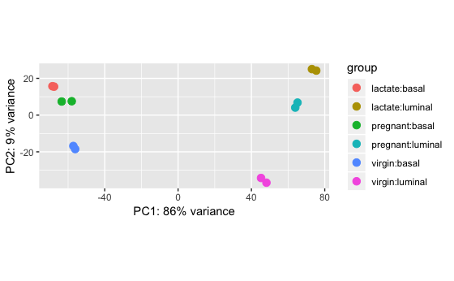

```r
vstcounts <- vst(ddsObj, blind=TRUE)
plotPCA(vstcounts, intgroup=c("Status", "CellType"))
```

## DESeq workflow

The main DESeq2 work flow is carried out in 3 steps:

First, Calculate the “median ratio” normalisation size factors…

```r
ddsObj <- estimateSizeFactors(ddsObj)
```

… then estimate dispersion …

```r
ddsObj <- estimateDispersions(ddsObj)
```

… finally, apply Negative Binomial GLM fitting and calculate Wald statistics

```r
ddsObj <- nbinomWaldTest(ddsObj)
```

## The `DESeq` command

In practice the 3 steps above can be performed in a single step using the `DESeq` wrapper function. Performing the three steps separately is useful if you wish to alter the default parameters of one or more steps, otherwise the `DESeq` function is fine.

```r
# rebuild a clean DDS object
ddsObj <- DESeqDataSetFromMatrix(countData = countdata,
                              colData = sampleinfo,
                              design = design)
```

```
some variables in design formula are characters, converting to factors
```

```r
# Run DESeq
ddsObj <- DESeq(ddsObj)
```

## Generate a results table

```r
res <- results(ddsObj, lfcThreshold = 0.05)
head(res)
```

```
log2 fold change (MLE): Status lactate vs virgin
Wald test p-value: Status lactate vs virgin
DataFrame with 6 rows and 6 columns
                            baseMean     log2FoldChange             lfcSE
                           <numeric>          <numeric>         <numeric>
ENSMUSG00000051951  193.628316332322  0.685666258943773 0.756712220191988
ENSMUSG00000102331 0.552133378452342   1.82614307383859  2.73990068529035
ENSMUSG00000025900  2.09442070179461  -3.02782655402946  1.54150999536643
ENSMUSG00000025902  52.4208304161579 -0.703252517806911  0.41735658148811
ENSMUSG00000098104 0.684213614702782  0.201738946689915   1.6866157166625
ENSMUSG00000103922  27.5871076674379   1.63592009157737 0.669531803485605
                                 stat             pvalue
                            <numeric>          <numeric>
ENSMUSG00000051951  0.840036994225487   0.40088764463888
ENSMUSG00000102331  0.648250895871568  0.516822688112713
ENSMUSG00000025900  -1.93175948451869 0.0533891989410818
ENSMUSG00000025902  -1.56521436771813  0.117532653746976
ENSMUSG00000098104 0.0899665200500909  0.928313820035451
ENSMUSG00000103922   2.36870016229403 0.0178507183525554
                                 padj
                            <numeric>
ENSMUSG00000051951  0.602630170611148
ENSMUSG00000102331                 NA
ENSMUSG00000025900  0.139965482961841
ENSMUSG00000025902  0.253397386566579
ENSMUSG00000098104                 NA
ENSMUSG00000103922 0.0598748090016512
```

### Independent filtering

You will notice that some of the adjusted p-values (`padj`) are NA. Remember in Session 2 we said that there is no need to pre-filter the genes as DESeq2 will do this through a process it calls ‘independent filtering’. The genes with `NA` are the ones DESeq2 has filtered out.

From DESeq2 manual: “The results function of the DESeq2 package performs independent filtering by default using the mean of normalized counts as a filter statistic. A threshold on the filter statistic is found which optimizes the number of adjusted p values lower than a [specified] significance level”.

### The default contrast of `results`

The `results` function has returned the results for the contrast “lactate vs virgin”. Let’s have a look at the model matrix to understand why DESeq2 has given us this particular contrast.

```r
modelMatrix
```

```
   (Intercept) CellTypeluminal Statuspregnant Statuslactate
1            1               0              0             0
2            1               0              0             0
3            1               0              1             0
4            1               0              1             0
5            1               0              0             1
6            1               0              0             1
7            1               1              0             0
8            1               1              0             0
9            1               1              1             0
10           1               1              1             0
11           1               1              0             1
12           1               1              0             1
attr(,"assign")
[1] 0 1 2 2
attr(,"contrasts")
attr(,"contrasts")$CellType
[1] "contr.treatment"

attr(,"contrasts")$Status
[1] "contr.treatment"
```

By default, `results` has returned the contrast encoded by the final column in the model matrix. DESeq2 has the command `resultsNames` that allows us to view the contrasts that are available directly from the model matrix.

```r
resultsNames(ddsObj)
```

```
[1] "Intercept"                 "CellType_luminal_vs_basal"
[3] "Status_pregnant_vs_virgin" "Status_lactate_vs_virgin"
```

Let’s just rename `res` so that we know which contrast results it contains.

```r
resLvV <- res
```

```r
# get the results for pregant versus virgin
resPvV <- results(ddsObj,
                  name="Status_pregnant_vs_virgin",
                  lfcThreshold = 0.05)
resPvV
```

```
log2 fold change (MLE): Status pregnant vs virgin
Wald test p-value: Status pregnant vs virgin
DataFrame with 22013 rows and 6 columns
                            baseMean     log2FoldChange             lfcSE
                           <numeric>          <numeric>         <numeric>
ENSMUSG00000051951  193.628316332322 -0.954402462919324 0.758163669842148
ENSMUSG00000102331 0.552133378452342  0.793605030301095  2.76321615795618
ENSMUSG00000025900  2.09442070179461 -0.422312119522277  1.28960999953541
ENSMUSG00000025902  52.4208304161579 -0.372373337372372 0.399035417679429
ENSMUSG00000098104 0.684213614702782   -1.4747163554633  1.79948663916514
...                              ...                ...               ...
ENSMUSG00000064367  54055.8663105821  0.344588799853029  0.16434684684871
ENSMUSG00000064368  13454.3113895505  0.426945077829144 0.156109922740747
ENSMUSG00000064370  111885.216173771  0.415862003187522 0.225727285622426
ENSMUSG00000064372   396.00873428211  0.262372947574112 0.261696769419213
ENSMUSG00000095742  632.014515495881 -0.191806454656629 0.355891725136255
                                 stat             pvalue
                            <numeric>          <numeric>
ENSMUSG00000051951  -1.19288551917507  0.232914211218661
ENSMUSG00000102331  0.269108527090803  0.787846168742311
ENSMUSG00000025900 -0.288701328042124  0.772809946326741
ENSMUSG00000025902 -0.807881513994719  0.419158794064789
ENSMUSG00000098104 -0.791734889526206  0.428515274239742
...                               ...                ...
ENSMUSG00000064367   1.79248221369415 0.0730557557819728
ENSMUSG00000064368   2.41461318544844 0.0157519280677921
ENSMUSG00000064370    1.6208142590236  0.105057479509062
ENSMUSG00000064372  0.811523000629448  0.417065389751763
ENSMUSG00000095742 -0.398453924722015  0.690295615234789
                                 padj
                            <numeric>
ENSMUSG00000051951  0.505464700486813
ENSMUSG00000102331                 NA
ENSMUSG00000025900                 NA
ENSMUSG00000025902   0.70311817082662
ENSMUSG00000098104                 NA
...                               ...
ENSMUSG00000064367  0.235513696692518
ENSMUSG00000064368 0.0796472672344595
ENSMUSG00000064370  0.303591430973306
ENSMUSG00000064372  0.701304827626084
ENSMUSG00000095742  0.914514952925036
```

Let’s get the top 100 genes by adjusted p-value

```r
topGenesPvV <- resPvV %>%
    as.data.frame() %>%
    filter(!is.na(padj)) %>%
    arrange(padj) %>%
    head(100)
head(topGenesPvV)
```

|  | baseMean | log2FoldChange | lfcSE | stat | pvalue | padj |
| --- | --- | --- | --- | --- | --- | --- |
| 1 | 1070630.8182 | 7.373737 | 0.4192957 | 17.46676 | 2.566762e-68 | 4.445119e-64 |
| 2 | 378557.8403 | 7.064615 | 0.4224252 | 16.60558 | 6.350703e-62 | 5.499073e-58 |
| 3 | 462.1139 | -9.302791 | 0.6316790 | -14.64793 | 1.388793e-48 | 8.017040e-45 |
| 4 | 11141.0955 | 5.446360 | 0.3695948 | 14.60075 | 2.777839e-48 | 1.202665e-44 |
| 5 | 511666.8987 | 7.617588 | 0.5360017 | 14.11859 | 2.917677e-45 | 1.010567e-41 |
| 6 | 451.5154 | -2.761016 | 0.2090023 | -12.97123 | 1.781576e-38 | 5.142222e-35 |

### Challenge 1

> Obtain results for basal vs luminal and find the top 200 genes (call the new results object `resBvL`.

**Solution**

```r
# resBvL <- results(ddsObj, name="CellType_basal_vs_luminal")
# topGenesBvL <- resBvL %>%
#     as.data.frame() %>%
#     filter(!is.na(padj)) %>%
#     arrange(padj) %>%
#     head(200)
# head(topGenesBvL)
```

## Contrasts

Suppose we want to find differentially expressed genes between **pregnant** and **lactate**. We don’t have a parameter that explicitly will allow us to test that hypothesis. We need to provide a contrast.

```r
resultsNames(ddsObj)
```

```
[1] "Intercept"                 "CellType_luminal_vs_basal"
[3] "Status_pregnant_vs_virgin" "Status_lactate_vs_virgin"
```

```r
resPvL <- results(ddsObj,
                  contrast=c("Status", "pregnant", "lactate"),
                  lfcThreshold = 0.05)
```

## Comparing two design models

```r
designC <- as.formula(~ CellType )
# Compare the designs
ddsObjC <- DESeq(ddsObj, test="LRT", reduced=designC)
```

```
found already estimated dispersions, replacing these
```

```r
resCvCS <- results(ddsObjC)
```

### Challenge 2

> 1.Fit a model with interaction: What is the rationale to include the interaction?  
> 2. Is the number of replicates good enough to include the interaction?  
> 3. Is the interaction needed in the model?

**Solution**

```r
# designI <- as.formula(~ CellType * Status)
#
# # Build model
# ddsObjI <- DESeqDataSetFromMatrix(countData = countdata,
#                               colData = sampleinfo,
#                               design = designI)
# # Run DESeq
# ddsObjI <- DESeq(ddsObjI)
#
# # Compare the models
# ddsObjI <- DESeq(ddsObjI, test="LRT", reduced=design)
# resIvA <- results(ddsObjI)
```

## Finally save the results in a new Rdata object

```r
save(resLvV, ddsObj, sampleinfo, file="results/DE.Rdata")
```